# MC1 Rag (Python 3.12.7)

## Table of Contents

- Introduction
  - Background
  - The Task
- The Data
  - Explorative Data Analysis
    - First look at the data
    - Data Types
  - The release date distribution
    - Missing Values
    - Non english text
    - Content length
    - Exporting the dataset
- The databases
  - FAISS
  - ChromaDB
  - Number of layers choice
  - Our chunking strategies
  - Our final embeddings
- Generate the databases
  - Defining a chunking class
    - The FIASS database works like this
    - ChromaDB Database creation
- Agent evaluation
  - Set up openai
  - Evaluation of the connectors
- Evaluating the results
  - Loading the evaluation result data
- Discussion of the results
  - Answer Relevancy
  - Contextual Precision
  - Contextual Recall
  - Contextual Relevancy
- Faithfulness
  - Final Evaluation and Best Configuration
  - 🏁 Selected Configuration: FAISS + Recursive Chunking + 12-Layer Embedding
- ADD ON
  - Experiment with the RAG

# Introduction

## Author: Tobias Lauber

### Co-Author: Nikodem Wojtczak

### Background

This work is based on the RAG-MC1 work I have done before with Nikodem Wojtczak. It aims to extend and improve our previous work and to make it more comprehensive and easier to read.

Here is the link for our previous work: https://gitlab.fhnw.ch/tobias.lauber1/npr_niko_tobias

## The Task

The task for this MC, is both the creation and evaluation of our own RAG (Retrieval Augmented Generation).

In order to do that we will do the following steps. We...:

- analyze our data with explorative data analysis
- clean our data (removing data that is useless/harmful for our RAG)
- apply different chunking techniques for our data
- use different embedding databanks
- experiment with a different numbers of layers
- choose different metrics, according to which we want to judge our RAG
- visualize our evaluations and discuss our conclusions

In order to make this jupyter notebook easy to follow, and easy to read, I will comment any action we do and try to visualize and explain my thoughtprocess for actions and approaches I take. That way I will learn more about RAG and NPR and the Jupyter Notebook is easier to read

TOC

# The Data

The data we work with is made available by https://www.anacode.de/, it incorperates a collection of ~ 10000 cleantech media articles. Furthermore, we have gotten provided a human created gold standard query-answer-source triplet of 23 questions for evaluation.

## Explorative Data Analysis

### First look at the data

First of, before we start creating the RAG, it is helpful to look at our data so we can see what we are working with.

The data we work with is in the "data" subfolder and is called "cleantech_media_dataset_v2_2024-02-23.csv"

```python
import pandas as pd
import matplotlib.pyplot as plt
import seaborn as sns
import warnings
```

We use the pandas library to read in the data, save it as "df" and use df.head() to quickly preview the first 5 rows of your DataFrame and understand its structure, columns, and data types.

```python
df = pd.read_csv('data/cleantech_media_dataset_v2_2024-02-23.csv')
df.head()
```

|  | Unnamed: 0 | title | date | author | content | domain | url |
| --- | --- | --- | --- | --- | --- | --- | --- |
| 0 | 1280 | Qatar to Slash Emissions as LNG Expansion Adva... | 2021-01-13 | NaN | ["Qatar Petroleum ( QP) is targeting aggressiv... | energyintel | https://www.energyintel.com/0000017b-a7dc-de4c... |
| 1 | 1281 | India Launches Its First 700 MW PHWR | 2021-01-15 | NaN | ["• Nuclear Power Corp. of India Ltd. ( NPCIL)... | energyintel | https://www.energyintel.com/0000017b-a7dc-de4c... |
| 2 | 1283 | New Chapter for US-China Energy Trade | 2021-01-20 | NaN | ["New US President Joe Biden took office this ... | energyintel | https://www.energyintel.com/0000017b-a7dc-de4c... |
| 3 | 1284 | Japan: Slow Restarts Cast Doubt on 2030 Energy... | 2021-01-22 | NaN | ["The slow pace of Japanese reactor restarts c... | energyintel | https://www.energyintel.com/0000017b-a7dc-de4c... |
| 4 | 1285 | NYC Pension Funds to Divest Fossil Fuel Shares | 2021-01-25 | NaN | ["Two of New York City's largest pension funds... | energyintel | https://www.energyintel.com/0000017b-a7dc-de4c... |

According to df.head() we can make a few assumptions, which we will obviously test later We see the data is structured in a title column with the article title, a content column contains the entire article and the source is in the url column.

Furthermore we believe that Unnamed: 0 is the ID column. In order for that to be true, it would have to be unique. Lets test that.

(columns like author are not as important to us. Date however could be, since information might be outdated)

```python
df['Unnamed: 0'].is_unique
```

```
True
```

'Unnamed: 0' is unique, so we believe it must be the ID column and rename it accordingly

```python
df = df.rename(columns={'Unnamed: 0':'ID'})
```

## Data Types

Next we check if all the data types are good for our analysis. The types are all fine, except for date. We want the column to be in datetime format. We also create a monthly column (year-month column), so we can analyse the distribution of article releases over time.

```python
df.dtypes
```

```
ID          int64
title      object
date       object
author     object
content    object
domain     object
url        object
dtype: object
```

```python
df['date'] = pd.to_datetime(df['date'],errors='coerce')
df['year_month'] = df['date'].dt.to_period('M')
```

## The release date distribution

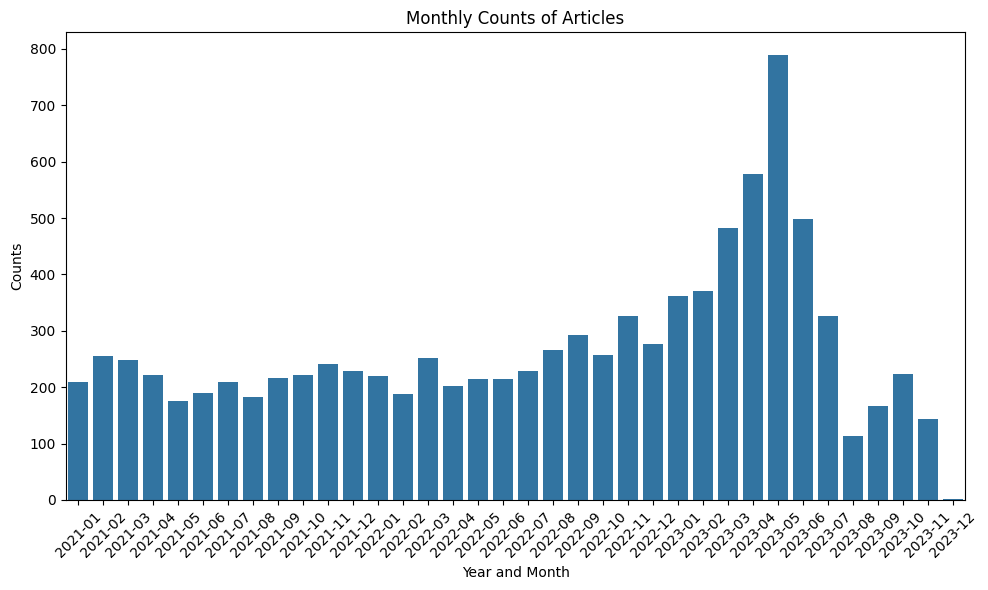

```python
monthly_counts = df.groupby('year_month').size().reset_index(name='Counts')

plt.figure(figsize=(10,6))
sns.barplot(x='year_month', y='Counts', data=monthly_counts)
# Step 4: Customize the plot
plt.title('Monthly Counts of Articles')
plt.xlabel('Year and Month')
plt.ylabel('Counts')

plt.xticks(rotation=45)
plt.tight_layout()
plt.show()
```

As we can see, our articles release date ranges from 2021 to 2023. There is a notable spike in articles in the time period of the first half of the year of 2023.

What we need to understand from this, is that all are articles are outdated by 1.4 - 3.4 years. This shouldn't matter to some questions, like for example this question from the eval.csv dataset:

- "What is Agrivoltaics?"

However other questions are not definitions, so some answers are rag give might already be outdated (new technology etc).

This might not be the fault of our rag then, but the data, so it is important to keep this knowledge in mind.

### Missing Values

Next we look, if there are any columns with missing values.

It seems only the author column has missing values, but we do not really care about that one.

```python
df.isna().sum()
```

```
ID               0
title            0
date             0
author        9562
content          0
domain           0
url              0
year_month       0
dtype: int64
```

### Non english text

The next thing we do, is checking if truly all the content is in english. If it isn't our rag wont work, because our embedding model isn't trained on non english text. We us langdetect to check, if there is non english content.

```python
from langdetect import detect, DetectorFactory
DetectorFactory.seed = 0 # otherwise we get different results. Reran it to find it out -_-

# Checks if string is english
def is_english(text):
    try:
        return detect(text) == 'en'
    except:
        return False


# Apply warning suppression only in this code block
with warnings.catch_warnings():
    warnings.simplefilter('ignore')

    # Apply the function to the 'content' column
    df['is_english'] = df['content'].apply(is_english)

# check how many non english articles there are
df['is_english'].value_counts()
```

```
is_english
True     9588
False       5
Name: count, dtype: int64
```

We see, there are 5 non english articles. Lets take a look at them, before we remove them. Here they are:

```python
df[df['is_english'] == False]
```

|  | ID | title | date | author | content | domain | url | year_month | is_english |
| --- | --- | --- | --- | --- | --- | --- | --- | --- | --- |
| 1251 | 8283 | International Energy Storage Conference ( IRES... | 2021-01-26 | NaN | ['EUROSOLAR veranstaltet vom 16. bis 18. März ... | eurosolar | https://www.eurosolar.de/2021/01/26/internatio... | 2021-01 | False |
| 1271 | 8304 | Open Letter to Presidents Putin, Biden, Zelens... | 2022-04-05 | NaN | ['EUROSOLAR, the European Association for Rene... | eurosolar | https://www.eurosolar.de/sektionen/russland/ | 2022-04 | False |
| 1273 | 8307 | Internationale Konferenz für Energiespeicher m... | 2022-09-26 | NaN | ['Die nun zu Ende gegangene „ Internationale E... | eurosolar | https://www.eurosolar.de/2022/09/26/internatio... | 2022-09 | False |
| 1274 | 8308 | Presentations, Poster and Photos of the IRES 2022 | 2022-11-09 | NaN | ['Photos from the IRES ( Copyright EUROSOLAR e... | eurosolar | https://www.eurosolar.de/2022/10/20/presentati... | 2022-11 | False |
| 2489 | 24652 | SMS group liefert Prozesstechnologie für das e... | 2022-07-13 | NaN | ['© SMS group liefert Prozesstechnologie für d... | decarbxpo | https://www.decarbxpo.com/en/News_Media/Magazi... | 2022-07 | False |

I will now go over each article, to look what is wrong. Lets start with the ID 8283

We see, it is completely in german, so we remove it.

```python
pd.set_option('display.max_colwidth', None)  # Show full content of each column
pd.set_option('display.max_rows', None)      # Show all rows in the DataFrame

# Print the specific content where ID is 8383
print(df['content'][df['ID'] == 8283])

# Reset options if needed
pd.reset_option('display.max_colwidth')
pd.reset_option('display.max_rows')
```

```
1251    ['EUROSOLAR veranstaltet vom 16. bis 18. März 2021 seine 15. International Renewable Energy Storage Conference ( IRES 2021) als globales Online-Event. Wissenschaftlern aus der ganzen Welt wird so die Teilnahme ermöglicht.', 'Die IRES-Konferenz widmet sich neusten wissenschaftlichen Erkenntni…
Name: content, dtype: object
```

Lets look at the next ID, ID 8304

We see there is some what I assume to be russian at the end. We can remove it.

```python
pd.set_option('display.max_colwidth', None)  # Show full content of each column
pd.set_option('display.max_rows', None)      # Show all rows in the DataFrame

# Print the specific content where ID is 8304
print(df['content'][df['ID'] == 8304])

# Reset options if needed
pd.reset_option('display.max_colwidth')
pd.reset_option('display.max_rows')
```

```
1271    ['EUROSOLAR, the European Association for Renewable Energy, calls for an immediate Climate Cease Fire and Permanent Peace Agreement across Eastern Europe – engaging in omnilateral Climate Peace Diplomacy.', 'The assault by the Russian military on the Ukrainian people and their government is …
Name: content, dtype: object
```

Next we look at the ID 8307

Again, it is a german article. We will remove that one too.

```python
pd.set_option('display.max_colwidth', None)  # Show full content of each column
pd.set_option('display.max_rows', None)      # Show all rows in the DataFrame

# Print the specific content where ID is 8307
print(df['content'][df['ID'] == 8307])

# Reset options if needed
pd.reset_option('display.max_colwidth')
pd.reset_option('display.max_rows')
```

```
1273    ['Die nun zu Ende gegangene „ Internationale Erneuerbare Energiespeicher Konferenz “ ( IRES), widmete sich vom 20 bis zum 22. September in der Messe Düsseldorf dem zentralen Schlüsselthema der Energiewende, den Speichertechnologien. Seit 2006 wird die IRES von EURSOLAR e.V. organisiert, die …
Name: content, dtype: object
```

```python
pd.set_option('display.max_colwidth', None)  # Show full content of each column
pd.set_option('display.max_rows', None)      # Show all rows in the DataFrame

# Print the specific content where ID is 8308
print(df['content'][df['ID'] == 8308])

# Reset options if needed
pd.reset_option('display.max_colwidth')
pd.reset_option('display.max_rows')
```

```
1274    ['Photos from the IRES ( Copyright EUROSOLAR e.V.)', 'Molten Salt Electrolyte in Na-ZnCl2 Solid-Electrolyte Battery for Electricity StorageSumit Kumar, Wenjin Ding *, Alexander Bonk, Meike V. F. Heinz, Norbert Weber, Thomas Bauer', 'Processing Of CNT/Inorganic Hybrid Electrodes Via Rapid Jou…
Name: content, dtype: object
```

Now, lets look at the last ID, ID 24652

One last time, we see a german article that needs to be removed!

```python
pd.set_option('display.max_colwidth', None)  # Show full content of each column
pd.set_option('display.max_rows', None)      # Show all rows in the DataFrame

# Print the specific content where ID is 24652
print(df['content'][df['ID'] == 24652])

# Reset options if needed
pd.reset_option('display.max_colwidth')
pd.reset_option('display.max_rows')
```

```
2489    ['© SMS group liefert Prozesstechnologie für das klimaneutrale Stahlwerk in Schweden. ( Quelle: SMS group)', 'SMS group, eines der weltweit führenden Unternehmen im metallurgischen Anlagenbau, wurde mit der Lieferung der kompletten Technologie und Ausrüstung für das Projekt H2 Green Steel in…
Name: content, dtype: object
```

```python
df = df[df['is_english'] != False]
df = df.drop(columns='is_english', axis=1)
```

### Content length

Last but not least, we want to take a look at how long our content column entries (articles) are. This is important knowledge, so we can better envision in how many chunks our content may be split, or if there are obvious outliers. We use a barplot with a trendline to show the frequency of the different content lengths (binsize 30).

As we can see, most articles are of a length from ~2000-7000 characters. But there are cases of articles that have over 18000 characters. This is pretty interesting information.

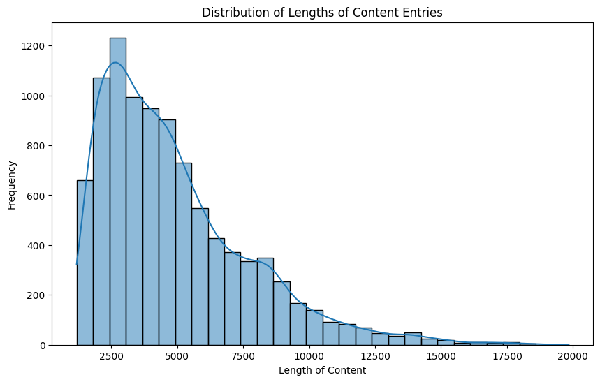

```python
import seaborn as sns

#Calculate the length of each entry in the content column
df['content_length'] = df['content'].apply(len)

# Plotting the distribution of the content lengths
plt.figure(figsize=(10, 6))

# binsizr 30
sns.histplot(df['content_length'], bins=30, kde=True)

# Adding labels and title
plt.xlabel('Length of Content')
plt.ylabel('Frequency')
plt.title('Distribution of Lengths of Content Entries')

plt.show()
```

Too make sure we dont miss any outliers ath the tails, I will also list the 5 shortest and longest articles

It seems there were no bad outliers, so we can keep them all.

```python
# The shortest articles
df['content_length'].sort_values(ascending=True).head(5)
```

```
500     1188
8703    1196
7373    1236
349     1240
1177    1245
Name: content_length, dtype: int64
```

```python
# The longest articles
df['content_length'].sort_values(ascending=False).head(5)
```

```
3417    19836
3003    19744
3542    19473
7065    18534
3061    18522
Name: content_length, dtype: int64
```

### Exporting the dataset

Now, for the rest of the rag, we will work with the cleaned dataset. This concludes our short explorative data analysis of the raw data.

```python
df.to_csv('data/cleantech_media_dataset_cleaned.csv', index=False)
```

We now export all of these articles into .txt files. In order to do that, we create the class **ArticlesExtractor** .

ArticlesExtractor works like this: It reads a CSV file that contains article data, processes each entry, and saves the article content as individual .txt files in a given directory. The filenames are based on the article titles, which are cleaned to remove any characters that are not allowed in filenames.

The class has two main parts:

- ___title_to_filename()__ is a helper method that turns a title into a valid filename by replacing spaces with underscores and removing characters like slashes, colons, or asterisks.
- extract_articles_from_csv() is the core method. It opens the CSV file, loops through each row, extracts the article content, and writes it to a text file. If the output folder doesn’t exist, it will be created automatically.

```python
import csv
import os
import re

class ArticlesExtractor:
    """
    ArticlesExtractor is a utility class designed to extract articles from a CSV file and save them as text files.
    Each article's title is sanitized to remove characters not allowed in filenames and spaces are replaced with
    underscores. The articles are then saved to the specified output directory, with the filenames derived from
    their titles.
    """
    def _title_to_filename(self, title: str) -> str:
        """
        Converts an article title into a safe filename by removing characters that are not allowed in filenames
        and replacing spaces with underscores. This method is used internally to sanitize article titles before
        saving them as text files.

        Args:
            title (str): The article's title that needs to be converted into a filename.

        Returns:
            str: A sanitized version of the title that can safely be used as a filename.
        """
        filename = re.sub(r'[<>:"/\\|?*]', '', title.replace(' ', '_'))
        return filename

    def extract_articles_from_csv(self, csv_file_path: str, output_directory: str) -> None:
        """
        Extracts articles from a CSV file and saves them as text files in the specified output directory. The CSV
        file should have at least two columns named "Text" and "Title". Each article is saved as a separate text file,
        with the file name derived from its title. The output directory is created if it does not already exist.

        Args:
            csv_file_path (str): The path to the CSV file containing the articles to be extracted. The CSV file
                                 should be encoded in UTF-8 and contain columns for "Text" and "Title".
            output_directory (str): The path to the directory where the extracted articles will be saved as text
                                    files. This directory will be created if it does not exist.

        Returns:
            None
        """
        os.makedirs(output_directory, exist_ok=True)  # Create the directory if it doesn't exist
        with open(csv_file_path, mode='r', encoding='utf-8') as csv_file:
            csv_reader = csv.DictReader(csv_file)
            for row in csv_reader:
                title = self._title_to_filename(row['title'])  # Sanitize article's title
                content_list = eval(row['content'])  # Convert string representation of list back to a list
                output_file_path = os.path.join(output_directory, f"{title}.txt")
                with open(output_file_path, mode='w', encoding='utf-8') as text_file:
                    for line in content_list:
                        cleaned_line = line.strip('"')  # Remove leading and trailing quotes
                        text_file.write(cleaned_line + "\n")
```

Now, lets run our class and put our .txt files into the articles folder. We now have text data we can work with

```python
# Extract articles
extractor = ArticlesExtractor()
extractor.extract_articles_from_csv(csv_file_path="data/cleantech_media_dataset_cleaned.csv",
                                    output_directory='articles')
```

🔝 Back to TOC

# The databases

In order to build the RAG, we need a DAtabase to store our embeddings. I have chosen 2 different databases here to store our embeddings created by the different chunking strategies and different #layers choice.

The reason for choosing each database are the following:

### FAISS

FAISS is a library developed by Facebook AI Research that specializes in efficient similarity search. I chose FAISS because it offers high performance for vector search, especially when working with large sets of embeddings. It allows for both exact and approximate nearest neighbor search, making it well-suited for experiments where retrieval speed and search accuracy are key variables. Since it doesn’t include additional document management layers, it keeps the focus strictly on the quality of the embeddings and the effectiveness of the chunking and layer configurations.

### ChromaDB

ChromaDB is a vector database designed specifically for use with large language models and retrieval-augmented generation pipelines. I chose ChromaDB for its simplicity and built-in support for storing both embeddings and associated metadata. It allows for easy experimentation with different document structures, and provides a persistent, lightweight solution that integrates smoothly into Python-based workflows. This makes it a strong choice when evaluating not just retrieval quality, but also how chunking strategies perform in a more complete, application-oriented setup.

### Number of layers choice

To find out if using more layers improves our RAG results, we create embeddings with both a 6-layer and a 12-layer model. This lets us compare how the number of layers affects performance.

### Our chunking strategies

We experiment with 3 different chunking strategies to see how the way we split text affects the performance of our RAG setup.

**Character based chunking:**  
This approach splits text into chunks based on a fixed number of characters. Advantage: Simple and fast to apply. Disadvantage: Doesn’t account for token boundaries or meaning, which can lead to poor context retention.

### Our final embeddings

Following our reasoning above, for our final embeddings, we have 12 different embeddings:

- 6Layer_RecursiveChunking_ChromaDB
- 6Layer_RecursiveChunking_FAISS
- 6Layer_CharacterChunking_ChromaDB
- 6Layer_CharacterChunking_FAISS
- 6Layer_TokenbasedChunking_ChromaDB
- 6Layer_TokenbasedChunking_FAISS
- 12Layer_RecursiveChunking_ChromaDB
- 12Layer_RecursiveChunking_FAISS
- 12Layer_CharacterChunking_ChromaDB
- 12Layer_CharacterChunking_FAISS
- 12Layer_TokenbasedChunking_ChromaDB
- 12Layer_TokenbasedChunking_FAISS

🔝 Back to TOC

# Generate the databases

Now, lets generate the databases!

We need the following packages, to create our chunking. Furthermore we ensure that nltk (Natural language toolkit) is up to date. It is a pretrained tokenization model, that we intend to use.

```python
import os
import nltk
import matplotlib.pyplot as plt
from nltk.tokenize import word_tokenize
from langchain_community.embeddings import HuggingFaceEmbeddings
from typing import List
from langchain.vectorstores import FAISS

# Ensure you have the necessary tokenizer downloaded
nltk.download('punkt')
```

```
True
```

## Defining a chunking class

### with different functions for chunking approaches

The DocumentChunker class is designed to read .txt files from a given directory, apply three different chunking methods to each document, and collect the resulting chunks for further analysis.

- The **init** method sets up the input directory and the maximum chunk size.
- **read_documents()** reads all .txt files in the specified directory and stores their contents along with filenames.
- **chunk_by_character()** splits a text into fixed-size chunks based on a defined number of characters.
- **chunk_by_token()** tokenizes the text using NLTK, then groups the tokens into chunks without exceeding the size limit.
- **chunk_recursively()** attempts to split text more naturally by breaking at the last space before the size limit, preserving word boundaries where possible.
- **process_documents()** runs all three chunking methods on each document, storing both the chunk contents and the length of each chunk for later analysis.
- **plot_histograms()** generates histograms of chunk lengths for each strategy, helping visualize how evenly the text is split under each method.

```python
class DocumentChunker:
    def __init__(self, directory, max_size=600):
        self.directory = directory
        self.max_size = max_size

    # Function to read text files from the directory
    def read_documents(self):
        documents = []
        for filename in os.listdir(self.directory):
            if filename.endswith(".txt"):
                filepath = os.path.join(self.directory, filename)
                with open(filepath, 'r', encoding='utf-8') as file:
                    documents.append((filename, file.read()))
        return documents

    # Chunk by character
    def chunk_by_character(self, text):
        return [text[i:i + self.max_size] for i in range(0, len(text), self.max_size)]

    # Chunk by token
    def chunk_by_token(self, text):
        tokens = word_tokenize(text)
        chunks = []
        current_chunk = []
        current_size = 0

        for token in tokens:
            token_size = len(token) + 1  # +1 for space or punctuation
            if current_size + token_size > self.max_size:
                chunks.append(" ".join(current_chunk))
                current_chunk = [token]
                current_size = token_size
            else:
                current_chunk.append(token)
                current_size += token_size

        if current_chunk:  # Add the last chunk
            chunks.append(" ".join(current_chunk))

        return chunks

    # Chunk recursively
    def chunk_recursively(self, text):
        if len(text) <= self.max_size:
            return [text]

        # Split the text into smaller chunks based on size
        chunks = []
        while len(text) > self.max_size:
            # Find the last space before the max_size limit
            split_index = text.rfind(" ", 0, self.max_size)
            if split_index == -1:  # If no space found, split at max_size
                split_index = self.max_size

            chunks.append(text[:split_index])
            text = text[split_index:].lstrip()  # Remove leading spaces for next chunk

        if text:  # Add remaining text
            chunks.append(text)

        return chunks

    # Process all documents in the directory and chunk them
    def process_documents(self):
        documents = self.read_documents()
        chunk_data = {
            'character_chunks': [],
            'token_chunks': [],
            'recursive_chunks': [],
            'all_character_chunks': [],
            'all_token_chunks': [],
            'all_recursive_chunks': []
        }

        for filename, document in documents:
            character_chunks = self.chunk_by_character(document)
            token_chunks = self.chunk_by_token(document)
            recursive_chunks = self.chunk_recursively(document)

            chunk_data['character_chunks'].extend([len(chunk) for chunk in character_chunks])
            chunk_data['token_chunks'].extend([len(chunk) for chunk in token_chunks])
            chunk_data['recursive_chunks'].extend([len(chunk) for chunk in recursive_chunks])

            chunk_data['all_character_chunks'].extend(character_chunks)
            chunk_data['all_token_chunks'].extend(token_chunks)
            chunk_data['all_recursive_chunks'].extend(recursive_chunks)

        return chunk_data

    # Function to plot histogram
    def plot_histograms(self, chunk_data):
        strategies = ['character_chunks', 'token_chunks', 'recursive_chunks']

        for strategy in strategies:
            plt.figure(figsize=(8, 6))
            plt.hist(chunk_data[strategy], bins=20, color='skyblue', edgecolor='black')
            plt.title(f"Distribution of Chunk Lengths ({strategy.replace('_', ' ').title()})")
            plt.xlabel('Chunk Length (characters)')
            plt.ylabel('Frequency')
            plt.grid(True)
            plt.show()
```

Now, we have to create one last class to start with the creation of the FIASS database.

### The FIASS database works like this:

The **FiassConnector** class handles both the creation and loading of a FAISS vector store. It uses a HuggingFace embedding model to convert the chunked documents into vectors. If the **chunked_documents** are provided, it can initialize a new FAISS database and save it locally. Later, the same database can be loaded again using the **load_db** method.

Once the database is loaded, the **retrieve** method allows us to perform similarity search. Given a query, it returns the top k most relevant text chunks based on semantic similarity.

```python
from langchain_community.embeddings import HuggingFaceEmbeddings
from typing import List
from langchain.vectorstores import FAISS


class FiassConnector():
    def __init__(self, embedding_model_name, db_path, chunked_documents = None) -> None:
        self.embedding_model_name = embedding_model_name
        self.db_path = db_path
        self.chunked_documents = chunked_documents
        self.embeddings = HuggingFaceEmbeddings(model_name=self.embedding_model_name)
        self.db = None

    def init_databse(self):
        self.db = FAISS.from_texts(self.chunked_documents, self.embeddings)
        self.db.save_local(self.db_path)

        print(f"FAISS DB saved at {self.db_path}")
        return self.db

    def load_db(self):
        self.db = FAISS.load_local(self.db_path, embeddings=self.embeddings, allow_dangerous_deserialization=True)
        return self.db

    def retrieve(self, query: str, k: int) -> List[str]:
        docs = self.db.similarity_search(query, k=5)

        rag_output = []
        for doc in docs:
            rag_output.append(doc.page_content)

        return rag_output
```

Now we can finally create the FIASS Database!

```python
directory_path = "articles"  # Specify the path to your directory
chunker = DocumentChunker(directory_path)
# Process documents and obtain chunk data
chunk_data = chunker.process_documents()


embeding = "all-MiniLM-L6-v2"
print("Chunking start")

chunks_token = chunk_data['all_token_chunks']

print("Creating db")

fiass_connector_token_L6 = FiassConnector(embedding_model_name=embeding, chunked_documents=chunks_token, db_path=f"databases/fiass_token_{embeding}")
fiass_connector_token_L6.init_databse()




embeding = "all-MiniLM-L6-v2"
print("Chunking start")

chunks_character = chunk_data['all_character_chunks']


fiass_connector_character_L6 = FiassConnector(embedding_model_name=embeding, chunked_documents=chunks_character, db_path=f"databases/fiass_character_{embeding}")
fiass_connector_character_L6.init_databse()



embeding = "all-MiniLM-L12-v2"
print("Chunking start")
chunks_recursive = chunk_data['all_recursive_chunks']
print("Creating db")
fiass_connector_recursive_L12 = FiassConnector(embedding_model_name=embeding, chunked_documents=chunks_recursive, db_path=f"databases/fiass_recursive_{embeding}")
fiass_connector_recursive_L12.init_databse()

embeding = "all-MiniLM-L6-v2"
print("Chunking start")
chunks_recursive = chunk_data['all_recursive_chunks']
print("Creating db")
fiass_connector_recursive_L6 = FiassConnector(embedding_model_name=embeding, chunked_documents=chunks_recursive, db_path=f"databases/fiass_recursive_{embeding}")
fiass_connector_recursive_L6.init_databse()


embeding = "all-MiniLM-L12-v2"
print("Chunking start")

chunks_token = chunk_data['all_token_chunks']

print("Creating db")

fiass_connector_token_L12 = FiassConnector(embedding_model_name=embeding, chunked_documents=chunks_token, db_path=f"databases/fiass_token_{embeding}")
fiass_connector_token_L12.init_databse()




embeding = "all-MiniLM-L12-v2"
print("Chunking start")

chunks_character = chunk_data['all_character_chunks']


fiass_connector_character_L12 = FiassConnector(embedding_model_name=embeding, chunked_documents=chunks_character, db_path=f"databases/fiass_character_{embeding}")
fiass_connector_character_L12.init_databse()
```

```
Chunking start
Creating db
```

```
FAISS DB saved at databases/fiass_token_all-MiniLM-L6-v2
Chunking start
FAISS DB saved at databases/fiass_character_all-MiniLM-L6-v2
Chunking start
Creating db
FAISS DB saved at databases/fiass_recursive_all-MiniLM-L12-v2
Chunking start
Creating db
FAISS DB saved at databases/fiass_recursive_all-MiniLM-L6-v2
Chunking start
Creating db
FAISS DB saved at databases/fiass_token_all-MiniLM-L12-v2
Chunking start
FAISS DB saved at databases/fiass_character_all-MiniLM-L12-v2
```

```
<langchain_community.vectorstores.faiss.FAISS at 0x7f2d2d4e56a0>
```

## ChromaDB Database creation

To create the ChromaDBs, we use the below created **ChromaConnector** class. It handles everything from initializing a new database to adding the embedded text chunks and saving the result.

Since we’re working with a lot of data, we add the documents in batches to avoid memory issues. The **init_database()** method checks if the number of documents is larger than a set batch size (here: 41,666), and if so, splits them up before adding them. Each batch is processed and added to a persistent Chroma database stored at the given path.

The **load_db()** method allows us to load an existing ChromaDB from disk, using the same embedding model that was used to create it. This makes it easy to resume work or run retrieval without rebuilding the entire database.

Finally, the **retrieve()** method takes a query string and returns the top-k most similar chunks using Chroma’s similarity search.

Each ChromaConnector instance is tied to a specific embedding model, a set of chunked documents, and an output path. This setup makes it easy to test different combinations — like chunking strategy (token, character, recursive) and model depth (6-layer vs. 12-layer).

```python
from langchain_community.embeddings import HuggingFaceEmbeddings
from typing import List
from langchain.vectorstores import FAISS
from langchain_community.embeddings import HuggingFaceEmbeddings
from typing import List
from langchain.vectorstores import Chroma
from itertools import islice

def chunked_iterable(iterable, size):
    iterator = iter(iterable)
    for first in iterator:
        yield [first, *islice(iterator, size - 1)]

def init_database_in_batches(self, batch_size=41666):
    chunked_batches = list(chunked_iterable(self.chunked_documents, batch_size))
    for i, batch in enumerate(chunked_batches):
        print(f"Processing batch {i+1} of {len(chunked_batches)}")
        db = Chroma.from_texts(batch, self.embeddings)
        db.save_local(f"{self.db_path}_batch_{i+1}")

    print(f"ChromaDB saved at {self.db_path}")
    return self.db


from langchain_community.embeddings import HuggingFaceEmbeddings
from typing import List
from langchain_chroma import Chroma  # Update import to the latest Chroma

from langchain_community.embeddings import HuggingFaceEmbeddings
from typing import List
from langchain_chroma import Chroma

class ChromaConnector:
    def __init__(self, embedding_model_name, db_path, chunked_documents=None) -> None:
        self.embedding_model_name = embedding_model_name
        self.db_path = db_path  # This will be used for persistent storage
        self.chunked_documents = chunked_documents
        self.embeddings = HuggingFaceEmbeddings(model_name=self.embedding_model_name)
        self.db = None

    def init_database(self, batch_size=41666):
        if len(self.chunked_documents) > batch_size:
            chunked_batches = [self.chunked_documents[i:i + batch_size] for i in range(0, len(self.chunked_documents), batch_size)]
        else:
            chunked_batches = [self.chunked_documents]

        # Initialize Chroma with persistent storage
        self.db = Chroma(embedding_function=self.embeddings, persist_directory=self.db_path)
        for i, batch in enumerate(chunked_batches):
            print(f"Processing batch {i+1} of {len(chunked_batches)}")
            self.db.add_texts(batch)

        # Save the database to disk
        # self.db.persist()
        print(f"ChromaDB saved at {self.db_path}")
        return self.db

    def load_db(self):
        # Load ChromaDB from the specified directory
        self.db = Chroma(embedding_function=self.embeddings, persist_directory=self.db_path)
        print(f"ChromaDB loaded from {self.db_path}")
        return self.db

    def retrieve(self, query: str, k: int) -> List[str]:
        docs = self.db.similarity_search(query, k=k)

        rag_output = []
        for doc in docs:
            rag_output.append(doc.page_content)

        return rag_output





embeding = "all-MiniLM-L6-v2"
print("Chunking start")
chunks_character = chunk_data['all_character_chunks']
print("Creating db")
chroma_connector_character_L6 = ChromaConnector(embedding_model_name=embeding, chunked_documents=chunks_character, db_path=f"databases/chroma_chunks_character_{embeding}")
chroma_connector_character_L6.init_database()



embeding = "all-MiniLM-L6-v2"
print("Chunking start")
chunks_recursive = chunk_data['all_recursive_chunks']
print("Creating db")
chroma_connector_recursive_L6 = ChromaConnector(embedding_model_name=embeding, chunked_documents=chunks_recursive, db_path=f"databases/chroma_recursive_{embeding}")
chroma_connector_recursive_L6.init_database()



embeding = "all-MiniLM-L6-v2"
print("Chunking start")
chunks_token = chunk_data['all_token_chunks']
print("Creating db")
chroma_connector_token_L6 = ChromaConnector(embedding_model_name=embeding, chunked_documents=chunks_token, db_path=f"databases/chroma_token_{embeding}")
chroma_connector_token_L6.init_database()



embeding = "all-MiniLM-L12-v2"
print("Chunking start")
chunks_recursive = chunk_data['all_recursive_chunks']
print("Creating db")
chroma_connector_recursive_L12 = ChromaConnector(embedding_model_name=embeding, chunked_documents=chunks_recursive, db_path=f"databases/chroma_recursive_{embeding}")
chroma_connector_recursive_L12.init_database()



embeding = "all-MiniLM-L12-v2"
print("Chunking start")
chunks_token = chunk_data['all_token_chunks']
print("Creating db")
chroma_connector_token_L12 = ChromaConnector(embedding_model_name=embeding, chunked_documents=chunks_token, db_path=f"databases/chroma_token_{embeding}")
chroma_connector_token_L12.init_database()



embeding = "all-MiniLM-L12-v2"
print("Chunking start")
chunks_character = chunk_data['all_character_chunks']
print("Creating db")
chroma_connector_character_L12 = ChromaConnector(embedding_model_name=embeding, chunked_documents=chunks_character, db_path=f"databases/chroma_chunks_character_{embeding}")
chroma_connector_character_L12.init_database()
```

```
Chunking start
Creating db
Processing batch 1 of 2
Processing batch 2 of 2
ChromaDB saved at databases/chroma_chunks_character_all-MiniLM-L6-v2
Chunking start
Creating db
Processing batch 1 of 2
Processing batch 2 of 2
ChromaDB saved at databases/chroma_recursive_all-MiniLM-L6-v2
Chunking start
Creating db
Processing batch 1 of 3
Processing batch 2 of 3
Processing batch 3 of 3
ChromaDB saved at databases/chroma_token_all-MiniLM-L6-v2
Chunking start
Creating db
Processing batch 1 of 2
Processing batch 2 of 2
ChromaDB saved at databases/chroma_recursive_all-MiniLM-L12-v2
Chunking start
Creating db
Processing batch 1 of 3
Processing batch 2 of 3
Processing batch 3 of 3
ChromaDB saved at databases/chroma_token_all-MiniLM-L12-v2
Chunking start
Creating db
Processing batch 1 of 2
Processing batch 2 of 2
ChromaDB saved at databases/chroma_chunks_character_all-MiniLM-L12-v2
```

```
<langchain_chroma.vectorstores.Chroma at 0x7f2cfb86a960>
```

🔝 Back to TOC

# Agent evaluation

## Set up openai

First, we set up openai and test gpt 4. We will need that for later! Lets try to have gpt 4 tell us a funny joke.

We do this by setting up a custom wrapper class AzureOpenAICustom, built on the DeepEvalBaseLLM from the package deepeval. This lets us use the Azure OpenAI GPT models within the deepeval framework. In our case we use gpt-4o.

```python
from openai import AzureOpenAI
from deepeval.models.base_model import DeepEvalBaseLLM

class AzureOpenAICustom(DeepEvalBaseLLM):
    def __init__(self, model):
        self.model = model

    def load_model(self):
        return self.model

    def generate(self, prompt: str) -> str:
        # Call the chat completion endpoint

        response = self.load_model().chat.completions.create(
            messages=[
                    {"role": "user", "content": prompt}
            ],
            model = "gpt-4o",
        )

        return response.choices[0].message.content

    async def a_generate(self, prompt: str) -> str:
        # Call the chat completion endpoint asynchronously

        response = self.load_model().chat.completions.create(
            messages=[
                    {"role": "user", "content": prompt}
            ],
            model = "gpt-4o",
        )


        return response.choices[0].message.content

    def get_model_name(self):
        return "Custom Azure OpenAI Model"


model = AzureOpenAI(
    api_key="4bb3848b9b284c4b9fabfc9e09d5ef9d",
    api_version="2024-02-15-preview",   # new version instead of last years
    azure_endpoint = "https://p-oai-htdsnlp-09.openai.azure.com/"
)

# Replace these with actual values
azure_openai = AzureOpenAICustom(
    model=model
)

# Example usage
print(azure_openai.generate("Write me a  joke"))
```

```
Sure! Here's a light-hearted one for you:

Why don’t skeletons fight each other?

Because they don’t have the guts! 💀
```

We see our gpt4o instance works. Now let us give each connector an evaluation dataset. Remember, we already defined the gpt4o model, tested it and saved it in the variable **azure_openai**.

We now go through each of our 12 connectors — covering all combinations of database type (FAISS/Chroma), chunking strategy, and embedding depth — and generate an evaluation dataset for each.

For each connector:

- We load the corresponding database from disk.
- Then, for every question in our evaluation DataFrame (df), we retrieve relevant context passages using the connector’s .retrieve() method.
- This retrieved context is combined with the question to create a prompt, which is passed to our GPT-4o model via azure_openai.generate().
- The model’s output, along with the input, expected answer, and retrieval context, is stored in a LLMTestCase.

After processing all questions, we collect the test cases in a EvaluationDataset, which is saved under the connector’s name. In the end, we have one dataset for each configuration, all stored in the datasets dictionary.

This setup allows us to later evaluate and compare the performance of each retrieval strategy using consistent prompts and expected outputs.

```python
# we need the evaluation dataframe for testing
df_eval = pd.read_csv('data/eval.csv', sep=';')
df_eval = df_eval.drop(columns=['example_id', 'question_id', 'article_url'])
```

```python
from deepeval.dataset import EvaluationDataset
from deepeval.test_case import LLMTestCase

# List of connectors with names for easy identification
connectors = [
    ('fiass_recursive_L12', fiass_connector_recursive_L12),
    ('fiass_character_L12', fiass_connector_character_L12),
    ('fiass_token_L12', fiass_connector_token_L12),
    ('fiass_token_L6', fiass_connector_token_L6),
    ('fiass_character_L6', fiass_connector_character_L6),
    ('fiass_recursive_L6', fiass_connector_recursive_L6),
    ('chroma_character_L12', chroma_connector_character_L12),
    ('chroma_recursive_L12', chroma_connector_recursive_L12),
    ('chroma_token_L12', chroma_connector_token_L12),
    ('chroma_token_L6', chroma_connector_token_L6),
    ('chroma_character_L6', chroma_connector_character_L6),
    ('chroma_recursive_L6', chroma_connector_recursive_L6)
]

# Dictionary to hold datasets for each connector
datasets = {}

# Iterate over each connector
for connector_name, connector in connectors:
    test_cases = []

    # Load the database for the current connector
    connector.load_db()

    # Loop through each row in the DataFrame
    for i, row in df_eval.iterrows():
        question = row['question']

        # Retrieve relevant passages from the connector
        retrieved = connector.retrieve(question, 4)

        # Generate prompt
        prompt = f"""
        Given the question below and the relevant passages retrieved from various articles, provide a short response by synthesizing information from the provided context. Ensure the answer directly addresses the question.

        Question:
        {question}

        Context:
        {retrieved}
        """

        try:
            # Generate output using Azure OpenAI
            output = azure_openai.generate(prompt)  # we defined azureopenai above
        except:
            output="Error"

        # Append the test case to the list
        test_cases.append(
            LLMTestCase(
                input=question,
                actual_output=output,
                expected_output=row['answer'],
                retrieval_context=retrieved
            )
        )

    # Create and store EvaluationDataset for this connector
    datasets[connector_name] = EvaluationDataset(test_cases=test_cases)

# Now, each connector has its EvaluationDataset stored in the datasets dictionary
```

```
ChromaDB loaded from databases/chroma_chunks_character_all-MiniLM-L12-v2
ChromaDB loaded from databases/chroma_recursive_all-MiniLM-L12-v2
ChromaDB loaded from databases/chroma_token_all-MiniLM-L12-v2
ChromaDB loaded from databases/chroma_token_all-MiniLM-L6-v2
ChromaDB loaded from databases/chroma_chunks_character_all-MiniLM-L6-v2
ChromaDB loaded from databases/chroma_recursive_all-MiniLM-L6-v2
```

## Evaluation of the connectors

To evaluate how well each RAG configuration (connector) performs, we use the deepeval library and define a set of metrics: contextual precision, contextual recall, contextual relevancy, answer relevancy, and faithfulness. All metrics are based on our previously defined azure_openai model (GPT-4o), which is used to assess the quality of the generated answers in relation to the expected outputs and retrieved context.

Since running evaluations for all 12 connectors in a single loop proved unstable, we instead evaluate them one by one across separate cells. Each evaluation is run using the evaluate() function on the corresponding EvaluationDataset. The result is then saved as a .pkl file inside the **evaluation_results/** directory for later analysis.

This setup ensures more reliable execution and allows progress to be saved incrementally, reducing the chance of losing data due to crashes or interruptions during evaluation.

```python
from deepeval import evaluate
from deepeval.metrics import (
    ContextualPrecisionMetric,
    ContextualRecallMetric,
    ContextualRelevancyMetric,
    AnswerRelevancyMetric,
    FaithfulnessMetric
)

# Define metrics for evaluation
contextual_precision = ContextualPrecisionMetric(model=azure_openai)
contextual_recall = ContextualRecallMetric(model=azure_openai)
contextual_relevancy = ContextualRelevancyMetric(model=azure_openai)
answer_relevancy = AnswerRelevancyMetric(model=azure_openai)
faithfulness = FaithfulnessMetric(model=azure_openai)


metrics = [
    contextual_precision,
    contextual_recall,
    contextual_relevancy,
    answer_relevancy,
    faithfulness
]
```

I split it into 12 different cells, since it seems prone to crashing. This is also why the enumeration for code executionis a bit inconsistent here in the jupyter notebook.

```python
import pickle
os.makedirs("evaluation_results", exist_ok=True)

results = evaluate(test_cases=datasets["fiass_recursive_L12"], metrics=metrics)
with open("evaluation_results/fiass_recursive_L12.pkl", "wb") as f:
    pickle.dump(results, f)
```

```python
results = evaluate(test_cases=datasets["fiass_character_L12"], metrics=metrics)
with open("evaluation_results/fiass_character_L12.pkl", "wb") as f:
    pickle.dump(results, f)
```

```python
results = evaluate(test_cases=datasets["fiass_token_L12"], metrics=metrics)
with open("evaluation_results/fiass_token_L12.pkl", "wb") as f:
    pickle.dump(results, f)
```

```python
results = evaluate(test_cases=datasets["fiass_token_L6"], metrics=metrics)
with open("evaluation_results/fiass_token_L6.pkl", "wb") as f:
    pickle.dump(results, f)
```

```python
results = evaluate(test_cases=datasets["fiass_character_L6"], metrics=metrics)
with open("evaluation_results/fiass_character_L6.pkl", "wb") as f:
    pickle.dump(results, f)
```

```python
results = evaluate(test_cases=datasets["fiass_recursive_L6"], metrics=metrics)
with open("evaluation_results/fiass_recursive_L6.pkl", "wb") as f:
    pickle.dump(results, f)
```

```python
results = evaluate(test_cases=datasets["chroma_character_L12"], metrics=metrics)
with open("evaluation_results/chroma_character_L12.pkl", "wb") as f:
    pickle.dump(results, f)
```

```python
results = evaluate(test_cases=datasets["chroma_recursive_L12"], metrics=metrics)
with open("evaluation_results/chroma_recursive_L12.pkl", "wb") as f:
    pickle.dump(results, f)
```

```python
results = evaluate(test_cases=datasets["chroma_token_L12"], metrics=metrics)
with open("evaluation_results/chroma_token_L12.pkl", "wb") as f:
    pickle.dump(results, f)
```

```python
results = evaluate(test_cases=datasets["chroma_token_L6"], metrics=metrics)
with open("evaluation_results/chroma_token_L6.pkl", "wb") as f:
    pickle.dump(results, f)
```

```python
results = evaluate(test_cases=datasets["chroma_character_L6"], metrics=metrics)
with open("evaluation_results/chroma_character_L6.pkl", "wb") as f:
    pickle.dump(results, f)
```

```python
results = evaluate(test_cases=datasets["chroma_recursive_L6"], metrics=metrics)
with open("evaluation_results/chroma_recursive_L6.pkl", "wb") as f:
    pickle.dump(results, f)
```

Now, lets just also put all of those pkl files inot one single pkl file called **combined_dict** .

```python
import os
import pickle

combined_dict = {}
results_dir = "evaluation_results"

# Loop through each .pkl file in the evaluation_results folder
for filename in os.listdir(results_dir):
    if filename.endswith(".pkl") and filename != "combined_dict.pkl":
        key = filename.replace(".pkl", "")
        file_path = os.path.join(results_dir, filename)

        with open(file_path, "rb") as f:
            combined_dict[key] = pickle.load(f)

# Save the combined dictionary
with open(os.path.join(results_dir, "combined_dict.pkl"), "wb") as f:
    pickle.dump(combined_dict, f)

print("✅ combined_dict.pkl saved successfully.")
```

```
✅ combined_dict.pkl saved successfully.
```

## Evaluating the results

Now then, we have already made the evaluatopn with deepeval. No we will both look at the results and analyze them.

### Loading the evaluation result data

First we load the entire data again with pickle. If you ran the notebook from the start, we theoretically don't need to do this. But this is made so we don't have to run the entire notebook if you (reader) want to experiment a bit yourself.

```python
import pickle
with open('evaluation_results/combined_dict.pkl', 'rb') as file:
    combined_dict = pickle.load(file)
```

Next we calculate the mean score each of the 5 metrics and put them in a new dictionary called extracted_metrics. If you want to see the numbers, simply remove the hashes in the code at the bottom. We comment it out, because there would be 5*12 lines otherways. As a reminder, the names of those metrics are:

- **Answer Relevancy:**  
  Measures how directly the model's answer addresses the question.  
  → High score = the answer is on-topic and useful.  
  *Important because we want responses that are actually helpful, not just fluent.*
- **Contextual Precision:**  
  Measures how much of the retrieved context was actually useful for generating the answer.  
  → High score = less irrelevant context was included.  
  *Helps us understand if our chunking or retrieval strategy is too noisy.*
- **Contextual Recall:** Measures how much of the necessary context was included in what was retrieved.  
  → High score = most of the useful context was retrieved.  
  *Relevant when we want to avoid missing key facts or explanations.*
- **Contextual Relevancy:** Measures how relevant the retrieved context is overall to the question.  
  → High score = better alignment between question and retrieval.  
  *Useful to detect whether our database is surfacing good support material.*
- **Faithfulness:**  
  Checks whether the model’s answer stays true to the retrieved context — i.e., no hallucinations.  
  → High score = the answer sticks to what was in the context.  
  *Critical in RAG to ensure the model doesn't make things up.*

```python
from collections import defaultdict

extracted_metrics = {}

for key, metrics in combined_dict.items():
    eval_example = metrics
    print(f"Processing key: {key}")
    extracted_metrics[key] = defaultdict(list)

    # Iterate through all test results
    for result in eval_example.test_results:
        for m in result.metrics_data:
            extracted_metrics[key][m.name].append(float(m.score))

    # Calculate the mean of each metric
    extracted_metrics[key] = {metric: sum(scores) / len(scores) for metric, scores in extracted_metrics[key].items()}

    # UNCOMMENT THIS TO PRINT THE METRICS
    #for metric, mean_score in extracted_metrics[key].items():
        #print(f'{metric}: {mean_score}')
```

```
Processing key: chroma_character_L6
Processing key: fiass_recursive_L6
Processing key: fiass_token_L6
Processing key: chroma_recursive_L12
Processing key: fiass_character_L12
Processing key: fiass_token_L12
Processing key: chroma_character_L12
Processing key: fiass_recursive_L12
Processing key: chroma_token_L12
Processing key: chroma_token_L6
Processing key: fiass_character_L6
Processing key: chroma_recursive_L6
```

## Discussion of the results

Lets go over each metric one by one together, and discuss what it means for our RAG. In order to do this, I have written a function that draws the plots, if given the metric. The figsize is predefined as one, that worked for me.

```python
import matplotlib.pyplot as plt
import numpy as np

data = extracted_metrics

# Separate and sort keys by database
chroma_keys = sorted([key for key in data.keys() if key.startswith("chroma")])
fiass_keys = sorted([key for key in data.keys() if key.startswith("fiass")])

# Clean x-axis labels
chroma_labels = sorted([key.replace("chroma_", "") for key in chroma_keys])
x = np.arange(len(chroma_labels))
width = 0.4

def draw_metrics_plot(metric):
    chroma_values = [data[key].get(metric, 0) for key in chroma_keys]
    fiass_values = [data[key].get(metric, 0) for key in fiass_keys]

    plt.figure(figsize=(12, 6))
    plt.bar(x - width / 2, chroma_values, width, label='Chroma', edgecolor='black', alpha=0.8)
    plt.bar(x + width / 2, fiass_values, width, label='Fiass', edgecolor='black', alpha=0.8)

    plt.xlabel('Configuration')
    plt.ylabel('Metric Value')
    plt.title(f'Comparison of {metric}')
    plt.xticks(x, chroma_labels, rotation=45, ha='right')
    plt.ylim(0, 1.1)
    plt.legend()
    plt.grid(axis='y', linestyle='--', alpha=0.7)
    plt.tight_layout()
    plt.show()
```

### Answer Relevancy

While this metric confirms that most answers are on-topic, we’ll need to look at contextual precision, recall, and faithfulness to understand whether those answers are well-grounded and supported by retrieved information.

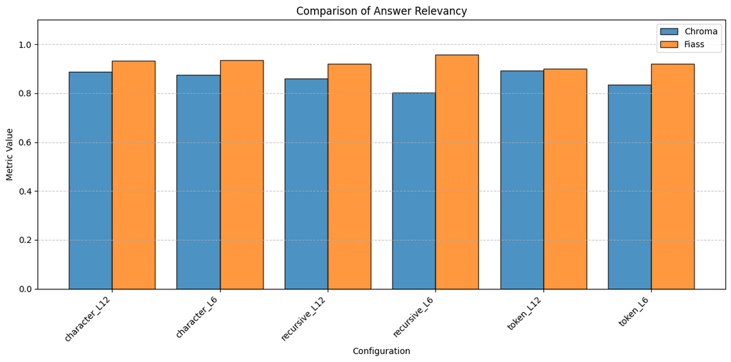

```python
draw_metrics_plot("Answer Relevancy")
```

### Contextual Precision

Contextual precision measures how much of the retrieved context was actually useful for generating the answer — in other words, how much "signal" versus "noise" was returned.

In this plot, we observe a clear and consistent advantage for FAISS over Chroma across every configuration. The margin is particularly wide in some setups, such as recursive_L12, where FAISS significantly outperforms Chroma (by ~0.15–0.2 points). This suggests that FAISS is more selective or accurate in retrieving relevant chunks, leading to cleaner input for the model.

Looking at chunking strategies:

Token-based chunking performs quite well too, especially with L6.

Lastly, we again see L6 outperforming L12 in multiple cases, or at least matching it. This may hint that the 6-layer model strikes a better balance between semantic embedding and generalization in this dataset.

**Note:** Contextual precision also depends on how bloated or noisy the retrieved chunks are. If the source text includes a lot of irrelevant content, even accurate retrievals will lower this score. For that reason, values close to 0.9 or 1.0 might not be realistic. What matters more here is the relative comparison between strategies, not the absolute numbers.

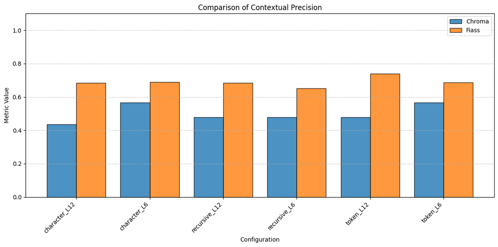

```python
draw_metrics_plot("Contextual Precision")
```

### Contextual Recall

Contextual recall measures how much of the relevant context was successfully retrieved — in other words, how completely the system captures the information needed to answer the question.

Looking at specific patterns:

As with precision, we again see a slight trend where L6 embeddings outperform or match L12 — especially in combination with FAISS.

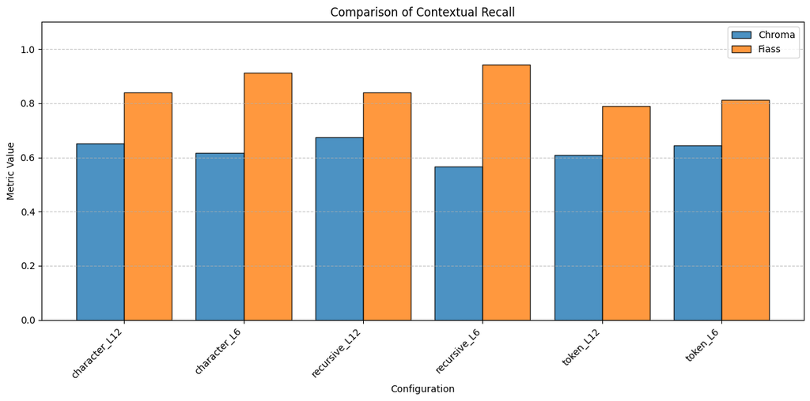

```python
draw_metrics_plot("Contextual Recall")
```

### Contextual Relevancy

Contextual relevancy measures how useful the retrieved context was in relation to the final answer. Unlike precision or recall (which focus on overlap or coverage), this metric reflects whether the model actually used the retrieved information meaningfully.

Overall, the scores are lower compared to other metrics, ranging roughly from 0.35 to 0.52. This is expected — the bar for contextual relevancy is higher, as it reflects not just what's retrieved, but whether it's integrated well into the model’s response.

Key takeaways:

FAISS trails behind. It seems to retrieve content that may be relevant but is not as effectively used in the final output.

These results suggest that Chroma tends to retrieve context that is more tightly aligned with how the model forms its answers, even if FAISS may retrieve more complete or precise chunks. This makes contextual relevancy a helpful complement to recall and precision — highlighting not just what’s retrieved, but what ends up being useful.

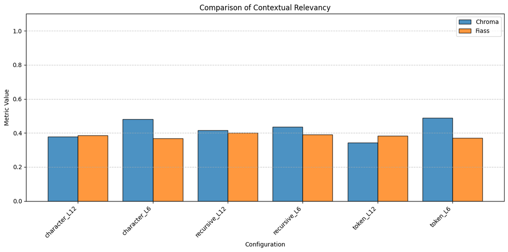

```python
draw_metrics_plot("Contextual Relevancy")
```

## Faithfulness

Faithfulness measures whether the generated answer stays true to the retrieved context — i.e., it checks for hallucinations or made-up content not supported by the evidence. It's a critical metric in RAG evaluation, since it speaks to how trustworthy the answers are!!!

In this chart, scores are generally very high, with all configurations landing between ~0.9 and 0.98, indicating that the generated outputs were largely grounded in the provided context.

Key observations:

Both Chroma and FAISS perform very well across the board.

The best-performing setup is FAISS with token-based chunking and 12-layer embeddings, slightly ahead of the rest.

This suggests that once a RAG system retrieves a reasonably relevant context, GPT-4 does a good job at sticking to the facts, regardless of chunking style or embedding depth.

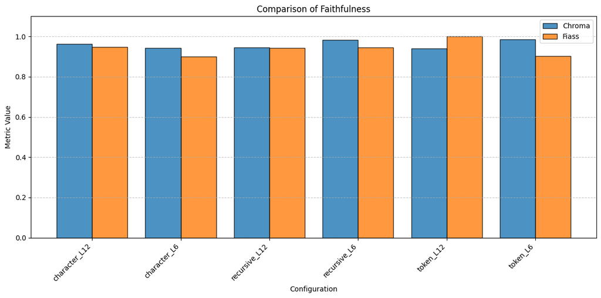

```python
draw_metrics_plot("Faithfulness")
```

### Selected Configuration

This combination delivers a **robust, high-coverage, and precise RAG pipeline**, making it the best all-rounder for this dataset and task.

🔝 Back to TOC

# ADD ON

## Experiment with the RAG

In order to experiment with the RAG I have made this cell here. Just execute it to run it.

There should already one execution be loaded. Since many articles were about Ukraine, I asked with 4 responses(chunks):

- *Who is the president of Russia?*

The RAG answers the questions and correctly displays the chunks from which it drew the knowledge. We can also be certain that the answer isn't simply chatgpt, since knowledge about former presidents/ministers is outdated.  
For example the RAG still believes Biden is president, and will claim that he is.

```python
from langchain.vectorstores import FAISS
from langchain_community.embeddings import HuggingFaceEmbeddings
from openai import AzureOpenAI
from deepeval.models.base_model import DeepEvalBaseLLM


class FiassConnector():
    def __init__(self, db_path) -> None:
        self.db_path = db_path
        self.embeddings = HuggingFaceEmbeddings(model_name="all-MiniLM-L12-v2")
        self.db = FAISS.load_local(self.db_path, embeddings=self.embeddings, allow_dangerous_deserialization=True)

    def retrieve(self, query: str, k: int):
        docs = self.db.similarity_search(query, k=k)

        rag_output = []
        for doc in docs:
            rag_output.append(doc.page_content)

        return rag_output


class AzureOpenAICustom(DeepEvalBaseLLM):
    def __init__(self, model):
        self.model = model

    def load_model(self):
        return self.model

    def generate(self, prompt: str) -> str:
        # Call the chat completion endpoint

        response = self.load_model().chat.completions.create(
            messages=[
                    {"role": "user", "content": prompt}
            ],
            model = "gpt-4o",
        )

        return response.choices[0].message.content

    async def a_generate(self, prompt: str) -> str:
        # Call the chat completion endpoint asynchronously

        response = self.load_model().chat.completions.create(
            messages=[
                    {"role": "user", "content": prompt}
            ],
            model = "gpt-4o",
        )


        return response.choices[0].message.content

    def get_model_name(self):
        return "Custom Azure OpenAI Model"


model = AzureOpenAI(
    api_key="4bb3848b9b284c4b9fabfc9e09d5ef9d",
    api_version="2024-02-15-preview",
    azure_endpoint = "https://p-oai-htdsnlp-09.openai.azure.com/"
)

# Replace these with actual values
azure_openai = AzureOpenAICustom(
    model=model
)

connector = FiassConnector(db_path=f"databases/fiass_recursive_all-MiniLM-L12-v2")





while(True):
    # User input for query and number of responses
    print("Type q to exit")
    query = input("Write here a query that you want to use: ")
    if query == "q":
        break
    number = input("How many responses do you want to get? ")
    try:
        num_responses = int(number)
        if num_responses <= 0:
            print("Please enter a positive integer.")
            exit()
    except ValueError:
        print("Please enter a valid integer.")
        exit()

    # Search for best fitted articles
    retrieved = connector.retrieve(query, num_responses)

    # Generate prompt
    prompt = f"""
    Given the question below and the relevant passages retrieved from various articles, provide a short response by synthesizing information from the provided context. Ensure the answer directly addresses the question.

    Question:
    {query}

    Context:
    {retrieved}
    """

    output = azure_openai.generate(prompt)

    print("Retrieved context chunks: ")

    print("\nRetrieved context chunks:\n")
    for i, chunk in enumerate(retrieved, 1):
        print(f"--- Chunk {i} ---")
        print(chunk)
        print()

    print("Output: ")
    print(output)
    print("\n\n")
```

```
Type q to exit
Retrieved context chunks:

Retrieved context chunks:

--- Chunk 1 ---
Russian President Vladimir Putin, in addition to the former President’ s repeated threats to pull the US out of NATO.
Well, that was then. Since President Biden took office in 2021, the US reaffirmed the NATO alliance, Putin launched his murderous rampage through Ukraine, somebody blew up Nordstream II, Trump is facing the strong possibility of criminal charges for his alleged role in the failed insurrection of Jan…
What Russia does have is the main base for the

--- Chunk 2 ---
in number than we typically presume. If his rule does end and he’ s toppled, who takes his place? Who takes over Russia, and will they look to bring back the brains and diversify away from fossil fuels? Or will they be even more entrenched in the fossil fuel world? How hard will it be to rebuild the…
If Putin does remain in power, well, it’ s hard to see much changing. The society will remain massively unbalanced economically, and even if Russian energy revenue declines, the oligarchs will remain rich and the poor majority will

--- Chunk 3 ---
continue to get by month to month. John McCain said Russia was “ a gas station masquerading as a country. ” It would remain a gas station, just a smaller one or one bringing in less revenue. The country won’ t be turned from a gas station into a Starbucks.
I think Putin’ s departure is more likely than not in the next few years ( but it’ s clearly very hard to predict). I just have a hard time seeing the people demand a more open and democratic system of rule now that millions have fled. It seems more likely that a power-hungry, money-hungry person wi…

--- Chunk 4 ---
To the shock of most Ukrainians as well as most Russians, Vladimir Putin decided to invade Ukraine in recent days and topple its democratically elected government. Following years of propaganda and blatant gaslighting, the military operation recently shifted from being a “ peacekeeping ” force in a …

Output:
The president of Russia is Vladimir Putin.



Type q to exit
```

🔝 Back to TOC